# Lab 4

Author

Jose Garcia

# Lab 4

```r
library(tidyverse)
library(ggridges)

avocado <- read_csv(here::here("Week 4", "Lab 4", "avocado.csv"))
```

## Problem 1

Briefly describe the dataset. What information does it contain?

- This dataset contains information about the weekly retail scan data on actual scales of Hass avocados. Each row represents a different weeks observation at a certain region.

## Problem 2

```r
#Renaming PLU's
avocado_clean <- avocado |>
  rename('Small_Avocado' = '4046', 'Large_Avocado' = '4225', "XL_Avocado" = '4770', 'Total_Volume' = 'Total Volume')

#Categorizing Regions
metro_regions <- tibble(region = c("LasVegas", "Seattle", "SanFrancisco", "SanDiego", "Sacramento", "Portland", "Tampa", "Pittsburgh", "Philadelphia", "Orlando", "Louisville", "LosAngeles", "Jacksonville", "Detroit", "Denver", "DallasFtWorth", "Chicago", "Boston", "Atlanta", "MiamiFtLauderdale", "Houston"))

avocado_metro <- avocado_clean |>
  semi_join(metro_regions, by = "region")

avocado_major <- avocado_clean |>
  anti_join(metro_regions, by = "region")
```

## Problem 3

```r
avocado_major |>
  filter(type == "organic" & year == 2017) |>
  group_by(region) |>
  summarise((tot_small = sum(Small_Avocado)))
```

```
# A tibble: 33 × 2
   region              `(tot_small = sum(Small_Avocado))`
   <chr>                                            <dbl>
 1 Albany                                           6806.
 2 BaltimoreWashington                             73690.
 3 Boise                                            2155.
 4 BuffaloRochester                                 4788.
 5 California                                    1526291.
 6 Charlotte                                        6684.
 7 CincinnatiDayton                                14545.
 8 Columbus                                        32217.
 9 GrandRapids                                      1864.
10 GreatLakes                                     202488.
# … with 23 more rows
```

Which major region sold the most organic, small Hass avocados in 2017?

- West

## Problem 4

```r
avocado_clean <- avocado_clean |>
  separate(Date, c("Year", "Month", "Day"))

avocado_clean |>
  group_by(Month) |>
  summarise(tot_vol = sum(Total_Volume))
```

```
# A tibble: 12 × 2
   Month     tot_vol
   <chr>       <dbl>
 1 01    1756531092.
 2 02    1760528797.
 3 03    1623951920.
 4 04    1235791676.
 5 05    1470745117.
 6 06    1202565549.
 7 07    1298880927.
 8 08    1128374772.
 9 09     976301645.
10 10    1028755872.
11 11     954168682.
12 12    1086806544.
```

Use the `separate()` function to split the `Date` variable into year, month, and day. In which month is the highest volume of avocado sales?

- February

## Problem 5

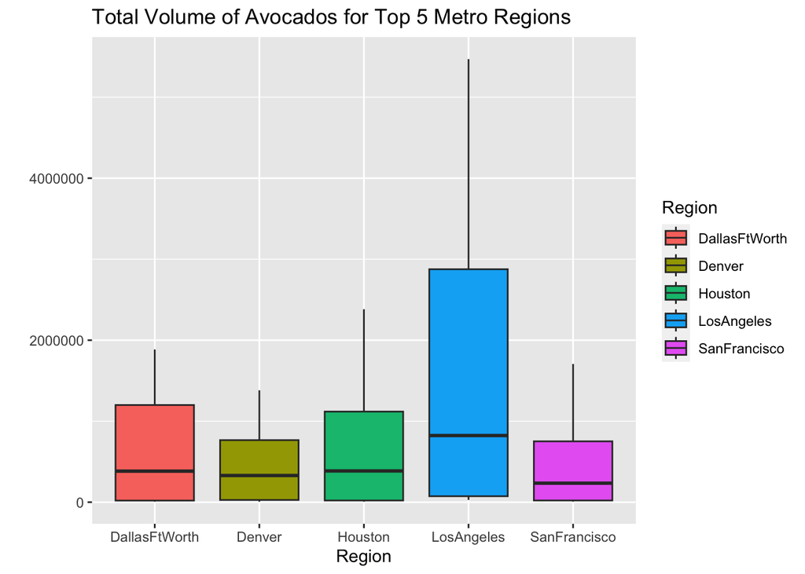

```r
options(scipen = 999) #from Google, removes scientific notation

metro_avg <- avocado_metro |>
  group_by(region) |>
  summarise(avg = mean(Total_Volume, na.rm = TRUE)) |>
  select(region, avg) |>
  top_n(5)

avocado_metro |>
  semi_join(metro_avg) |> #returns rows from x with a match in y
  ggplot(aes(x = region, y = Total_Volume, fill = region)) +
  geom_boxplot(position = "dodge") +
  labs(x = "Region", y = "", title = "Total Volume of Avocados for Top 5 Metro Regions", fill = "Region")
```

Which metro area regions sold the most total avocados? Plot density ridges of the total volume for **only the five regions** with the highest averages for the `Total Volume` variable.

- Los Angeles

## Problem 6

```r
avocado_cali <- avocado_clean |>
  filter(region %in%
           c("LosAngeles", "SanDiego", "Sacramento", "SanFrancisco")
         )

prices <- avocado_cali |>
  select(region, type, AveragePrice) |>
  group_by(region, type) |>
  summarise(avg = mean(AveragePrice)) |>
  pivot_wider(names_from = region, values_from = avg) |>
  summarise(diff = across(.cols = 'LosAngeles': 'SanFrancisco', .fns = diff))
```

## Problem 7

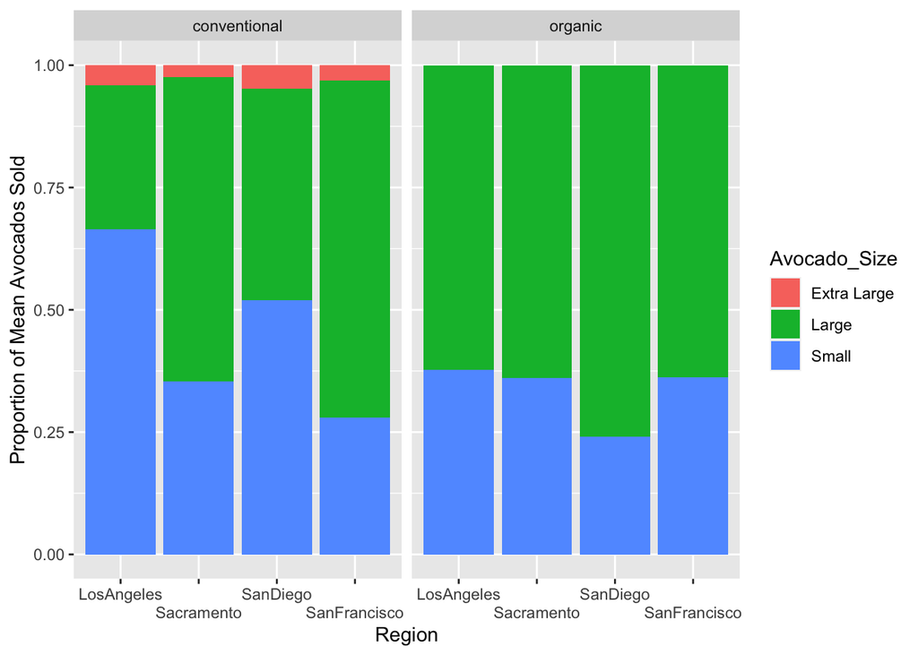

```r
conventional <- avocado_cali |>
  group_by(region, type) |>
  mutate(Small = sum(Small_Avocado)/sum(Small_Avocado, Large_Avocado, XL_Avocado),
         Large = sum(Large_Avocado)/sum(Small_Avocado, Large_Avocado, XL_Avocado),
         'Extra Large' = sum(XL_Avocado)/sum(Small_Avocado, Large_Avocado, XL_Avocado)) |>
  pivot_longer(cols = Small: 'Extra Large', names_to = "Avocado_Size", values_to = "Proportions")

conventional |>
  ggplot(aes(x = region, y = Proportions, fill = Avocado_Size)) +
  geom_col(position = "fill") +
  facet_wrap(~ type) +
  scale_x_discrete(guide = guide_axis(n.dodge = 2)) +
  labs(x = "Region", y = "Proportion of Mean Avocados Sold")
```